# Supplementary Material for **Amazing continuity of mining technology in the southern African Stone Age**

Armando Falcucci, Gunther H. D. Möller, Julia Becher, Bob Forrester, Jörg Linstädter, Gregor D. Bader

## Supplementary Figures

### Figure S1

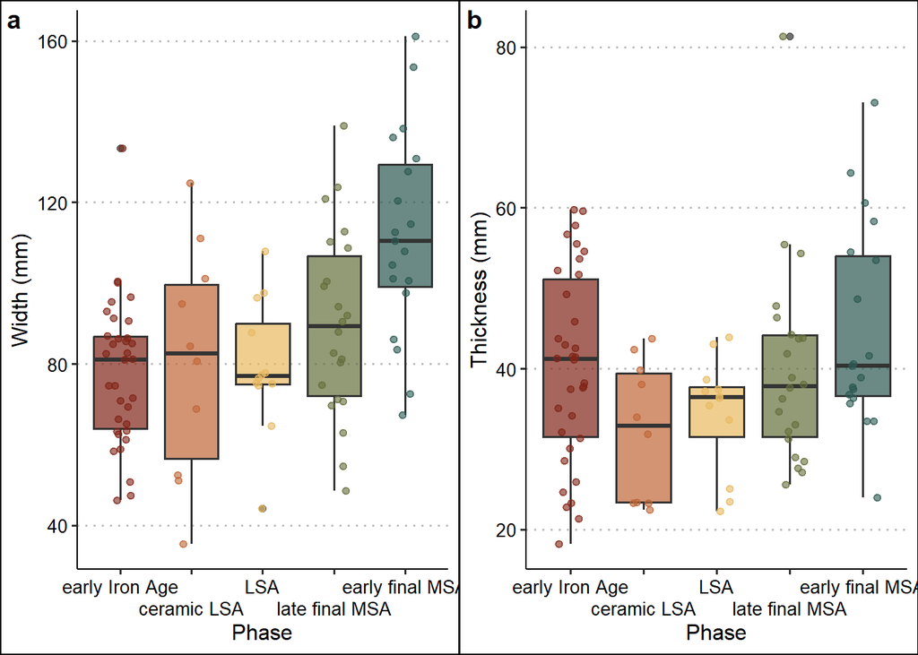

**Figure S1.** Boxplots with jittered points comparing width (mm) and thickness (mm) across chronological phases at Castle Cavern and Lion Cavern.

### Figure S2

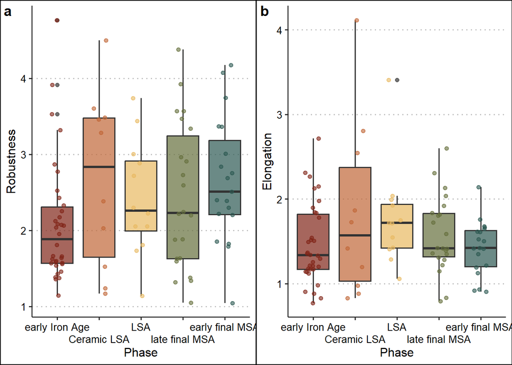

**Figure S2.** Boxplots with jittered points comparing robustness and elongation across chronological phases at Castle Cavern and Lion Cavern.

### Figure S3

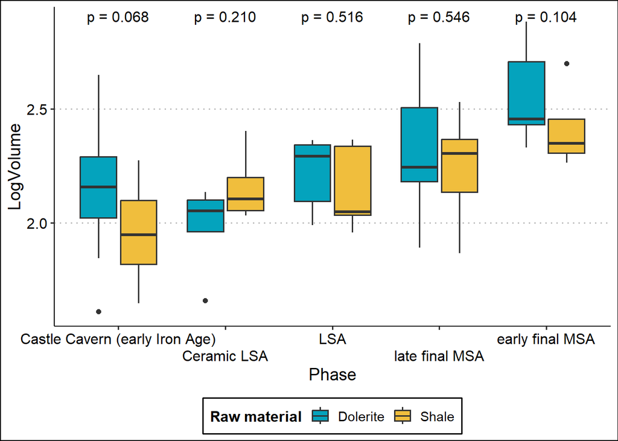

**Figure S3.** Comparison of logarithmically transformed log-volume (LogVolume) values sorted according to chronological phase and the most common raw materials (i.e., dolerite and shale).

### Figure S4

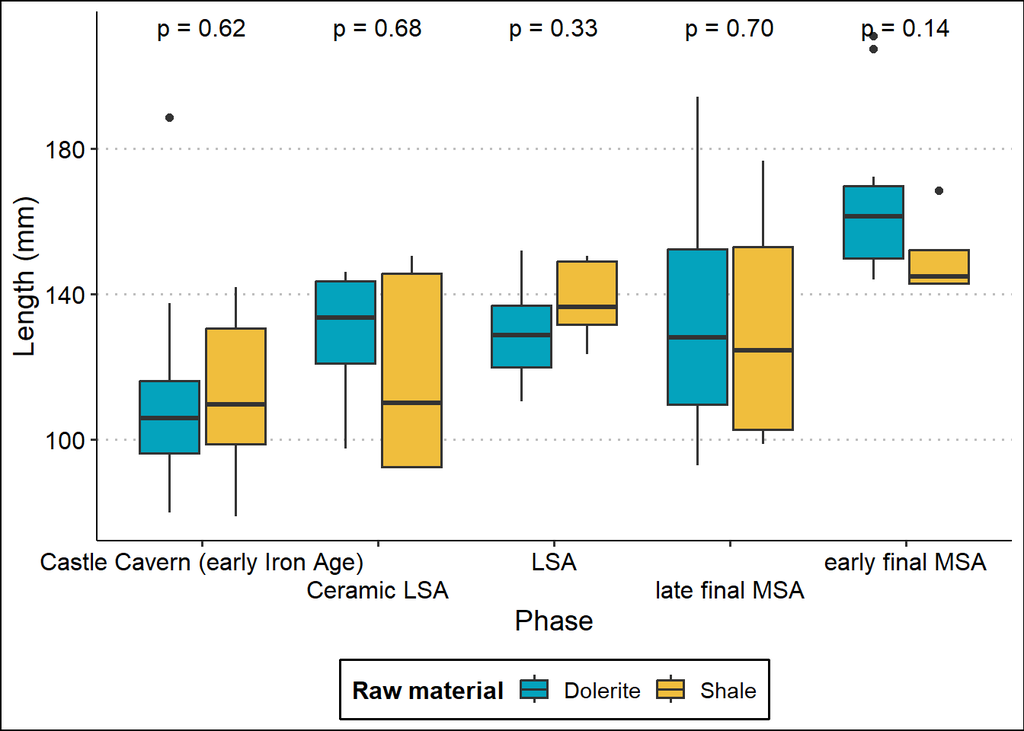

**Figure S4.** Comparison of length values (in mm) sorted according to chronological phase and the most common raw materials (i.e., dolerite and shale).

### Figure S5

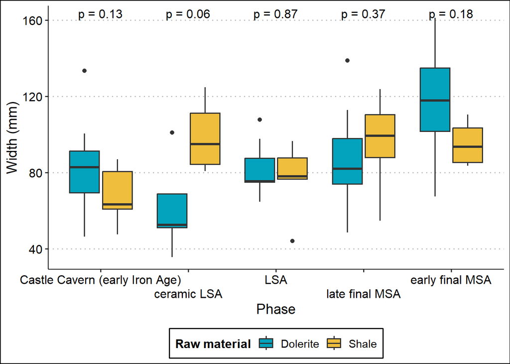

**Figure S5.** Comparison of width values (in mm) sorted according to chronological phase and the most common raw materials (i.e., dolerite and shale).

### Figure S6

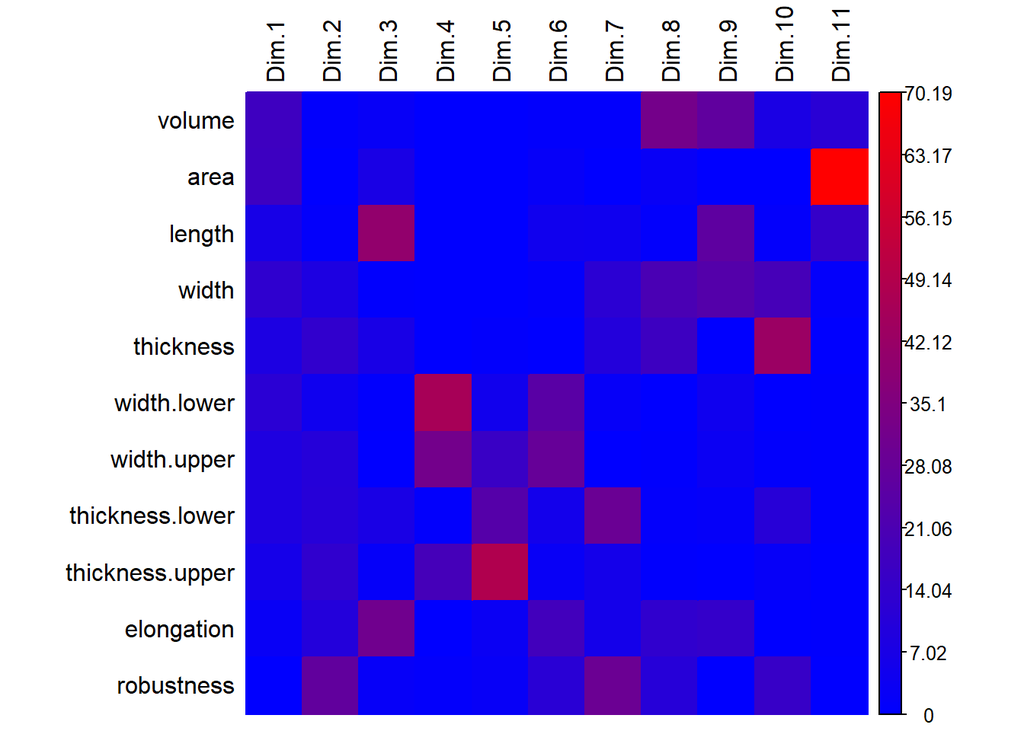

**Figure S6.** Heatmap showing the contribution of each variable to the dimensions (Dim1-Dim11) in the PCA of metric variables, with higher contributions indicated by warmer colors.

### Figure S7

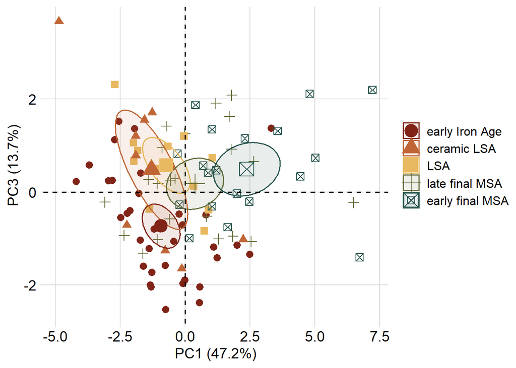

**Figure S7.** Distribution of the mining tools in the PC1 to PC3 space, sorted according to chronological phase.

### Figure S8

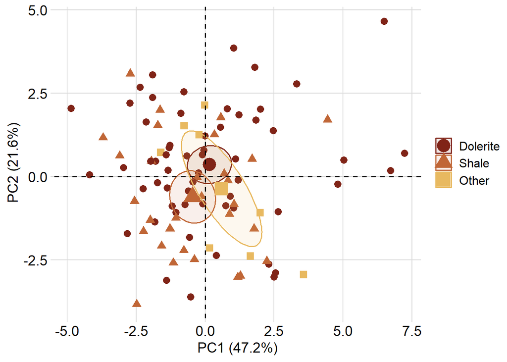

### Figure S9

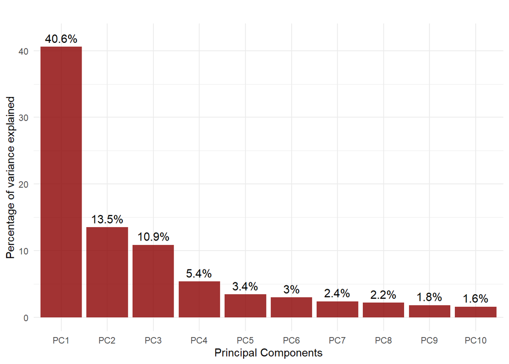

**Figure S9.** Scree plot dispaying the percentage of variance explained by the first ten principal components of the 3DGM analysis.

### Figure S10

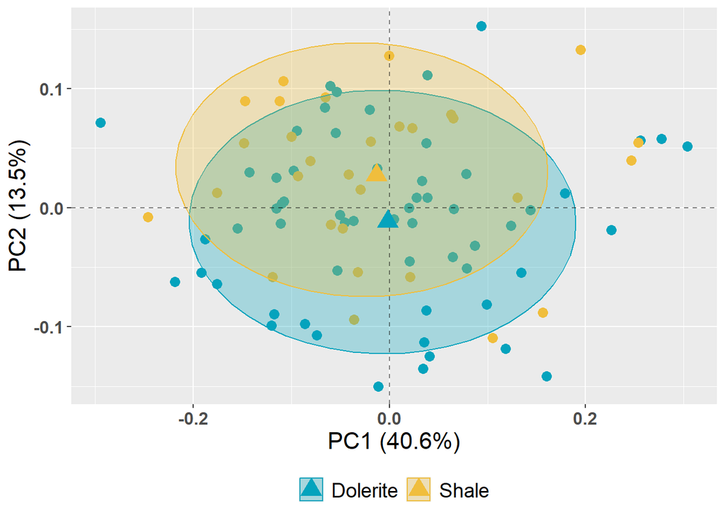

**Figure S10.** PCA biplot showing the shape variability of the mining tools along PC1 and PC2, sorted by the most common raw materials (dolerite and shale). Mean values are represented by triangles, and the confidence ellipses correspond to 80% of the variability.

## Supplementary Tables

### Table S1

| Phase | variable | n | mean | sd | min | median | max |
| --- | --- | --- | --- | --- | --- | --- | --- |
| Castle Cavern (early Iron Age) | volume | 34 | 145.4 | 82.0 | 40.8 | 115.5 | 446.5 |
| Castle Cavern (early Iron Age) | length | 34 | 108.0 | 22.3 | 78.7 | 104.3 | 188.7 |
| Castle Cavern (early Iron Age) | width | 34 | 77.9 | 17.9 | 46.3 | 81.1 | 133.4 |
| Castle Cavern (early Iron Age) | thickness | 34 | 40.3 | 12.0 | 18.2 | 41.2 | 59.7 |
| Ceramic LSA | volume | 10 | 127.4 | 53.4 | 45.7 | 119.8 | 253.2 |
| Ceramic LSA | length | 10 | 123.2 | 23.6 | 92.2 | 127.2 | 150.5 |
| Ceramic LSA | width | 10 | 80.5 | 28.6 | 35.5 | 82.6 | 124.8 |
| Ceramic LSA | thickness | 10 | 32.2 | 8.6 | 22.5 | 32.9 | 43.7 |
| LSA | volume | 12 | 164.6 | 58.8 | 90.9 | 161.2 | 231.6 |
| LSA | length | 12 | 132.9 | 13.8 | 110.4 | 130.3 | 152.0 |
| LSA | width | 12 | 79.6 | 16.6 | 44.1 | 76.9 | 107.9 |
| LSA | thickness | 12 | 34.4 | 7.2 | 22.2 | 36.5 | 43.9 |
| late final MSA | volume | 22 | 219.3 | 121.7 | 73.6 | 190.9 | 613.7 |
| late final MSA | length | 22 | 134.8 | 30.7 | 92.9 | 127.4 | 194.2 |
| late final MSA | width | 22 | 89.9 | 23.2 | 48.6 | 89.2 | 138.9 |
| late final MSA | thickness | 22 | 39.9 | 12.6 | 25.6 | 37.8 | 81.3 |
| early final MSA | volume | 19 | 327.5 | 160.0 | 159.1 | 269.8 | 764.6 |
| early final MSA | length | 19 | 153.6 | 27.1 | 103.4 | 148.6 | 211.0 |
| early final MSA | width | 19 | 112.0 | 25.5 | 67.3 | 110.5 | 161.2 |
| early final MSA | thickness | 19 | 44.7 | 12.7 | 24.0 | 40.4 | 73.1 |

**Table S1.** Descriptive statistics for artifact dimensions across the chronological phases at Castle Cavern and Lion Cavern. All measurements are rounded to one decimal place. sd = standard deviation.

### Table S2

Wilcoxon Pairwise Tests

|  | statistic..W | p.value |
| --- | --- | --- |
| Early Iron Age : Ceramic LSA | 46130 | <2e-16 |
| Early Iron Age : LSA | 999398 | <2e-16 |
| Early Iron Age : Late final MSA | 825597 | <2e-16 |
| Early Iron Age : Early final MSA | 982144 | <2e-16 |
| Ceramic LSA : LSA | 998497 | <2e-16 |
| Ceramic LSA : Late final MSA | 980120 | <2e-16 |
| Ceramic LSA : Early final MSA | 993511 | <2e-16 |
| LSA : Late final MSA | 33003 | <2e-16 |
| LSA : Early final MSA | 104585 | <2e-16 |
| Late final MSA : Early final MSA | 764631 | <2e-16 |

**Table S2.** Results of the Wilcoxon rank-sum test for pairwise comparisons of morphological disparity (measured as the sum of variances) among the chronological phases.

### Table S3

Wilcoxon Pairwise Tests

|  | statistic..W | p.value |
| --- | --- | --- |
| Early Iron Age : Ceramic LSA | 140988 | < 2e-16 |
| Early Iron Age : LSA | 910198 | < 2e-16 |
| Early Iron Age : Late final MSA | 124672 | < 2e-16 |
| Early Iron Age : Early final MSA | 158940 | < 2e-16 |
| Ceramic LSA : LSA | 971239 | < 2e-16 |
| Ceramic LSA : Late final MSA | 523084 | 0.738 |
| Ceramic LSA : Early final MSA | 627066 | < 2e-16 |
| LSA : Late final MSA | 12552 | < 2e-16 |
| LSA : Early final MSA | 21671 | < 2e-16 |
| Late final MSA : Early final MSA | 603994 | 8.06e-15 |

**Table S3.** Results of the Wilcoxon rank-sum test for pairwise comparisons of metric disparity (measured as the sum of variances) among the chronological phases.